# Differential equations in Maple

### A guest lecture by Robert M. Corless

[Editor-in-Chief, Maple Transactions](https://mapletransactions.org/index.php/maple)

We have a "Student Paper" column, and submissions from students are welcome.

[Home page](https://rcorless.github.io/)

Maple has several features for solving differential equations. SymPy in Python has many *very* similar features, so learning Maple's features will help you to understand SymPy's (which are weaker, but don't cost money).

Let's begin with the simplest differential equation of all:

\begin{equation} y' = f(x) \end{equation}

```python
dsolve( diff(y(x),x) = f(x), y(x) );
```

```
kilobytes used=1799, alloc=5424, time=0.25
```

$$y \left(x \right) = \int f \left(x \right)d x +c_{1}$$

```python
dsolve( diff( y(x), x ) = 1/(1+x), y(x) );
```

$$y \left(x \right) = \ln \left(1+x \right)+c_{1}$$

Now let's add an initial condition:

```python
dsolve( { diff(y(x),x)=sqrt(x), y(0)=3}, y(x) );
```

$$y \left(x \right) = \frac{2 x^{\frac{3}{2}}}{3}+3$$

Notice the details of the syntax.

y(x) means "y" is a function of "x"

(Other variable names are possible: you could have y(t) being a function of t or u(v) where u is a function of v or whatever you want, almost.)

diff( y(x), x ) means the derivative of y with respect to x

{ } are "set brackets" so

{ diff(y(x),x)=sqrt(x), y(0)=3 }

is the set containing the differential equation and an initial condition.

Now let's try a harder equation.

```python
dsolve( {diff(y(x),x) = mu*y(x), y(0)=C}, y(x) );
```

```
kilobytes used=5093, alloc=13872, time=0.78
```

$$y \left(x \right) = C \,{\mathrm e}^{\mu x}$$

That is (of course) the exponential growth equation (if $\mu > 0$) (the Greek letters are just spelled out in Maple input). The constant C is the initial concentration/population.

```python
Logistic := diff( y(t), t ) = mu*y(t)*( L - y(t) );
```

$$\frac{d}{d t}y \left(t \right) = \mu y \left(t \right) \left(L -y \left(t \right)\right)$$

```python
LogisticSolution := dsolve( {Logistic, y(0)=varepsilon}, y(t) );
```

$$y \left(t \right) = \frac{L \varepsilon}{\left(-\varepsilon +L \right) {\mathrm e}^{-\mu L t}+\varepsilon}$$

```python
limit( rhs(LogisticSolution), t=infinity ) assuming mu>0, L>0, varepsilon > 0;
```

$$L$$

"Nondimensionalization" helps in symbolic computation, too.

```python
step1 := PDETools:-dchange( {y(t)=L*Y(t)}, Logistic, {Y(t)});
```

$$L \left(\frac{d}{d t}Y \left(t \right)\right) = \mu L Y \left(t \right) \left(L -L Y \left(t \right)\right)$$

```python
step2 := normal( step1/L );
```

$$\frac{d}{d t}Y \left(t \right) = -\mu Y \left(t \right) L \left(Y \left(t \right)-1\right)$$

I always forget which way the "change of variables" command wants the transformation written. Every code writer has their own logic, so one has to read the documentation or do trial-and-error. I am leaving my mistakes in this Jupyter Notebook so you can learn from them.

```python
step3 := PDETools:-dchange( {tau=mu*L*t}, step2, {tau} );
```

```
Runtime error: Error, (in dchange/info) the new variables are not contained in the rhs of the direct transformation equations
```

```python
step3 := PDETools:-dchange( {t=tau/(mu*L)}, step2, {tau} );
```

$$\left(\frac{\partial}{\partial \tau}Y \left(\tau , L , \mu \right)\right) \mu L = -\mu Y \left(\tau , L , \mu \right) L \left(Y \left(\tau , L , \mu \right)-1\right)$$

```python
step4 := normal( step3/(L*mu) );
```

$$\frac{\partial}{\partial \tau}Y \left(\tau , L , \mu \right) = -Y \left(\tau , L , \mu \right) \left(Y \left(\tau , L , \mu \right)-1\right)$$

Maple is correct but pedantic: $Y$ is a function of $\tau$ and *also* a function of those constants $L$ and $\mu$. But the derivatives are only with respect to $\tau$ so it's really an ordinary differential equation, not a partial differential equation.

```python
step5 := eval( step4, Y(tau,L,mu) = Y(tau) ); # Remove clutter
```

[output not shown]

$$\frac{d}{d \tau}Y \left(\tau \right) = -Y \left(\tau \right) \left(Y \left(\tau \right)-1\right)$$

```python
nondimensionalSolution := dsolve( {step5, Y(0)=s}, Y(tau) );
```

$$Y \left(\tau \right) = -\frac{s}{\left(s -1\right) {\mathrm e}^{-\tau}-s}$$

```python
limit( rhs(nondimensionalSolution), tau=infinity );
```

$$1$$

```python
eval( nondimensionalSolution, tau=0 );
```

$$Y \left(0\right) = s$$

One reason to nondimensionalize is so we can plot things "all at once".

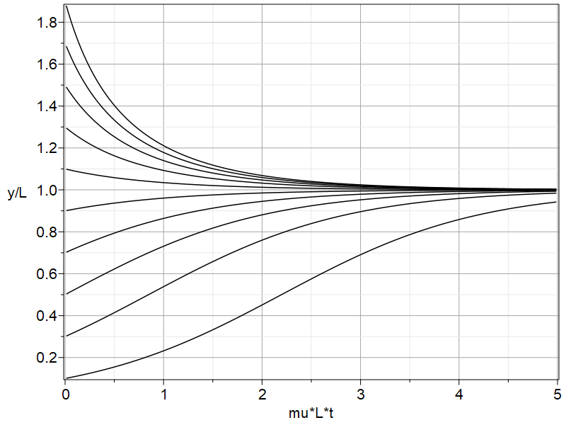

```python
plot( [seq( eval( rhs(nondimensionalSolution), s=sigma),
             sigma=[0.1, 0.3, 0.5, 0.7, 0.9, 1.1, 1.3, 1.5, 1.7, 1.9] )]
             , tau=0..5, labels=[mu*L*t, y/L], gridlines );
```

## Some limitations

Maple's "dsolve" command is very strong, but it can't solve *every* equation. Here's one where the best it can do is to "reduce the order". The output is very hard to read, too (it prints better in a Maple worksheet---the Jupyter Notebook interface is quite new and not all the wilder things look good in it yet).

```python
dsolve( diff(y(x),x,x) + y(x)^3/(1+x), y(x) );
```

```
kilobytes used=25135, alloc=18748, time=2.72
```

$$y \left(x \right) = \left(\frac{\textit{\_a}}{\sqrt{-{\mathrm e}^{-2 \left(\int \textit{\_}b\left(\textit{\_a} \right)d \textit{\_a} \right)-2 c_{1}}}}\right)\boldsymbol{\mathrm{where}}\left[\left\{\frac{d}{d \textit{\_a}}\textit{\_}b\left(\textit{\_a} \right)=\left(4 \textit{\_a}^{3}+3 \textit{\_a} \right) \textit{\_}b\left(\textit{\_a} \right)^{3}+4 \textit{\_}b\left(\textit{\_a} \right)^{2}\right\}, \left\{\textit{\_a} =y \left(x \right) \sqrt{1+x}, \textit{\_}b\left(\textit{\_a} \right)=\frac{\sqrt{1+x}}{\left(-1-x \right) \left(2 \left(\frac{d}{d x}y \left(x \right)\right) x +2 \frac{d}{d x}y \left(x \right)+y \left(x \right)\right)}\right\}, \left\{x =-{\mathrm e}^{-2 \left(\int \textit{\_}b\left(\textit{\_a} \right)d \textit{\_a} \right)-2 c_{1}}-1, y \left(x \right)=\frac{\textit{\_a}}{\sqrt{-{\mathrm e}^{-2 \left(\int \textit{\_}b\left(\textit{\_a} \right)d \textit{\_a} \right)-2 c_{1}}}}\right\}\right]$$

## Use of special functions

Maple's knowledge of special functions and *linear* second order differential equations is extremely strong. So for most equations like the following, Maple will readily give a solution. But you might have to look up what the answer means!

```python
LinearODE := diff( y(t), t, t) + (1+t)*diff(y(t),t) + t*y(t);
```

$$\frac{d^{2}}{d t^{2}}y \left(t \right)+\left(1+t \right) \left(\frac{d}{d t}y \left(t \right)\right)+t y \left(t \right)$$

```python
dsolve( LinearODE, y(t) );
```

$$y \left(t \right) = c_{1} {\mathrm e}^{-t}+c_{2} {\mathrm e}^{-t} \mathrm{erf}\left(\frac{\sqrt{2} \left(-1+t \right)}{2}\right)$$

"erf" is the "error function". You can find help on that [The Maple Help pages](https://www.maplesoft.com/support/help/Maple/view.aspx?path=erf)

If you want official instruction on special functions you can go to the Digital Library of Mathematical Functions

or to Fredrik Johansson's [The Function Grimoire](https://fungrim.org/)

Or you can use the FunctionAdvisor in Maple itself (not yet in the Jupyter Notebook interface).

## Boundary conditions

The easiest kind of problem to solve has it's conditions specified at only one point---"initial conditions" also called the Cauchy specification.

But frequently in practice we know things or want things about the solution to happen at different places. Most commonly, just two: the beginning and the end.

```python
BoundaryConditions := {y(-3)=1, y(2)=-1};
```

$$\{y \left(-3\right) = 1, y \left(2\right) = -1\}$$

```python
soln := dsolve( {LinearODE} union BoundaryConditions, y(t) );
```

$$y \left(t \right) = \frac{{\mathrm e}^{-3-t} \left(-\mathrm{erf}\left(\frac{\sqrt{2} \left(-1+t \right)}{2}\right) {\mathrm e}^{5}-{\mathrm e}^{5} \mathrm{erf}\left(2 \sqrt{2}\right)-\mathrm{erf}\left(\frac{\sqrt{2} \left(-1+t \right)}{2}\right)+\mathrm{erf}\left(\frac{\sqrt{2}}{2}\right)\right)}{\mathrm{erf}\left(\frac{\sqrt{2}}{2}\right)+\mathrm{erf}\left(2 \sqrt{2}\right)}$$

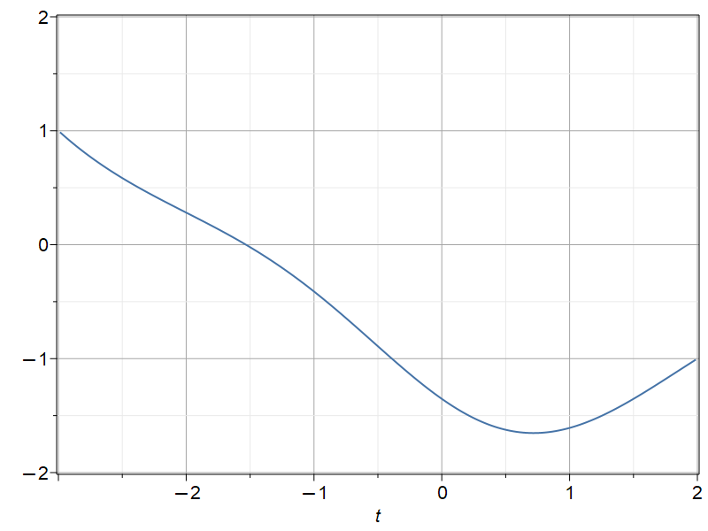

```python
plot( rhs( soln ), t=-3..2, thickness=2, color="Executive Blue",
 gridlines, view=[-3..2, -2..2]);
```

Sometimes Maple can solve the differential equation but cannot identify the arbitrary constants that come up because the boundary conditions give nonlinear algebraic equations to solve. Sometimes the solutions don't exist or sometimes there are infinitely many solutions (this is called an *eigenvalue* problem).

```python
dsolve( {diff(y(t),t,t) + (2*n+1)^2*y(t) = 0, y(-Pi/2)=0, y(Pi/2)=0 }, y(t) )
   assuming n::integer ;
```

$$y \left(t \right) = c_{2} \cos \left(\left(2 n +1\right) t \right)$$

Maple can give answers that are different on different intervals using its "piecewise" function.

```python
psol := dsolve( {diff(y(t),t,t) + y(t) = abs(t), y(-Pi)=0, y(Pi)=0}, y(t) )
```

$$y \left(t \right) = \sin \left(t \right) c_{2} +\cos \left(t \right) \pi -\left(\left\{\begin{array}{cc} t & t \le 0 \\ -t +2 \sin \left(t \right) & 0<t \end{array}\right.\right)$$

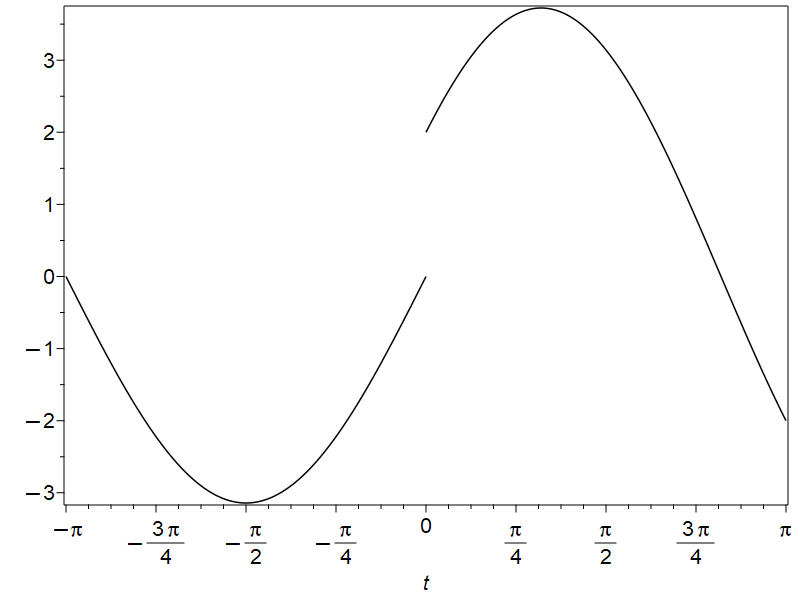

```python
plot( diff(eval(rhs(psol), c__2=0),t,t,t), t=-Pi..Pi, discont=true );
```

Piecewise functions occur naturally as input, also.

```python
psol := dsolve( {diff(y(t),t,t) = piecewise(t<0, sin(t), cos(t)/(1+t)),
         y(-Pi)=0, D(y)(-Pi)=0}, y(t) );
```

```
kilobytes used=72004, alloc=24074, time=6.69
```

$$y \left(t \right) = -\pi -\sin \left(t \right)-\left(\left\{\begin{array}{cc} t & t <0 \\ -\cos \left(1\right) \left(1+t \right) \mathrm{Ci}\left(1+t \right)-\sin \left(1\right) \left(1+t \right) \mathrm{Si}\left(1+t \right)+ \\ \mathrm{Ci}\left(1\right) \left(1+t \right) \cos \left(1\right)+\left(1+t \right) \mathrm{Si}\left(1\right) \sin \left(1\right)+2 t & 0\le t \end{array}\right.\right)$$

That answer contains "Sine integrals" and "Cosine integrals" Si and Ci. You can look them up, but they are defined by integrals.

```python
diff( Ci(t), t );
```

$$\frac{\cos \left(t \right)}{t}$$

```python
Ci(0);
```

```
Runtime error: Error, (in Ci) numeric exception: division by zero
```

```python
series( Ci(t), t );
```

$$\gamma +\ln \left(t \right)-\frac{1}{4} t^{2}+\frac{1}{96} t^{4}+\mathrm{O}\left(t^{6}\right)$$

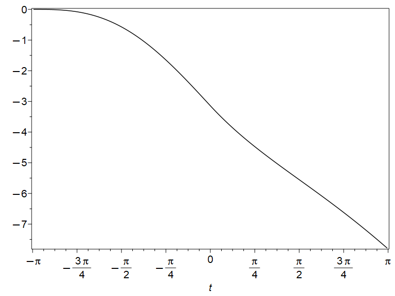

```python
plot( eval(y(t), psol), t=-Pi..Pi );
```

You can solve differential equations in series.

```python
dsolve( {diff(y(t),t) = y(t)^2-t, y(0)=-1/2}, y(t), series );
```

$$y \left(t \right) = -\frac{1}{2}+\frac{1}{4} t -\frac{5}{8} t^{2}+\frac{11}{48} t^{3}-\frac{13}{96} t^{4}+\frac{41}{320} t^{5}+\mathrm{O}\left(t^{6}\right)$$

```python
Order := 13;
```

$$13$$

```python
dsolve( {diff(y(t),t) = y(t)^2-t, y(0)=-1/2}, y(t), series );
```

$$y \left(t \right) = -\frac{1}{2}+\frac{1}{4} t -\frac{5}{8} t^{2}+\frac{11}{48} t^{3}-\frac{13}{96} t^{4}+\frac{41}{320} t^{5}-\frac{463}{5760} t^{6}+\frac{4219}{80640} t^{7}-\frac{141}{3584} t^{8}+\frac{15679}{580608} t^{9}-\frac{106609}{5806080} t^{10}+\frac{43993}{3379200} t^{11}-\frac{34728973}{3832012800} t^{12}+\mathrm{O}\left(t^{13}\right)$$

```python
Order := 233;
bigugly := dsolve( {diff(y(t),t) = y(t)^2-t, y(0)=-1/2}, y(t), series ):
biguglypolynomial := convert( rhs(bigugly), polynom ):
```

```
kilobytes used=91535, alloc=24074, time=8.38
```

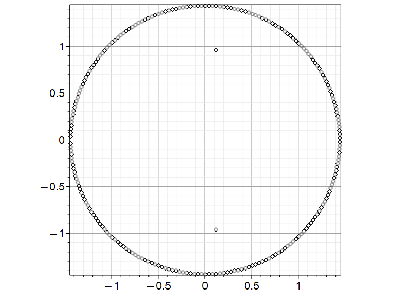

```python
rts := fsolve(biguglypolynomial,t,complex):
plots[pointplot]( [seq([Re(rts[i]),Im(rts[i])],
                  i=1..numelems([rts]))], scaling=constrained, gridlines );
```

```python
rts[1];
```

$$- 1.435830380- 0.03872885917 \,\mathrm{I}$$

```python
refsol := dsolve( {diff(y(t),t) = y(t)^2-t, y(0)=-1/2}, y(t) );
```

$$y \left(t \right) = -\frac{-\frac{\left(3^{\frac{5}{6}} \pi -3 \Gamma \left(\frac{2}{3}\right)^{2} 3^{\frac{2}{3}}\right) \mathit{Ai}^{\prime}\left(t \right)}{3 \,3^{\frac{1}{6}} \Gamma \left(\frac{2}{3}\right)^{2}+\pi 3^{\frac{1}{3}}}+\mathit{Bi}^{\prime}\left(t \right)}{-\frac{\left(3^{\frac{5}{6}} \pi -3 \Gamma \left(\frac{2}{3}\right)^{2} 3^{\frac{2}{3}}\right) \mathit{Ai}\left(t \right)}{3 \,3^{\frac{1}{6}} \Gamma \left(\frac{2}{3}\right)^{2}+\pi 3^{\frac{1}{3}}}+\mathit{Bi}\left(t \right)}$$

```python
den := denom(rhs(refsol));
```

$$\left(3 \,3^{\frac{1}{6}} \Gamma \left(\frac{2}{3}\right)^{2}+\pi 3^{\frac{1}{3}}\right) \left(3^{\frac{5}{6}} \pi \mathit{Ai}\left(t \right)-3 \Gamma \left(\frac{2}{3}\right)^{2} 3^{\frac{2}{3}} \mathit{Ai}\left(t \right)-3 \,3^{\frac{1}{6}} \Gamma \left(\frac{2}{3}\right)^{2} \mathit{Bi}\left(t \right)-\pi 3^{\frac{1}{3}} \mathit{Bi}\left(t \right)\right)$$

That solution involves Airy functions (which are quite interesting---[Sir George Biddell Airy](https://en.wikipedia.org/wiki/George_Biddell_Airy) was an astronomer, and he needed these functions to explain the rainbow).

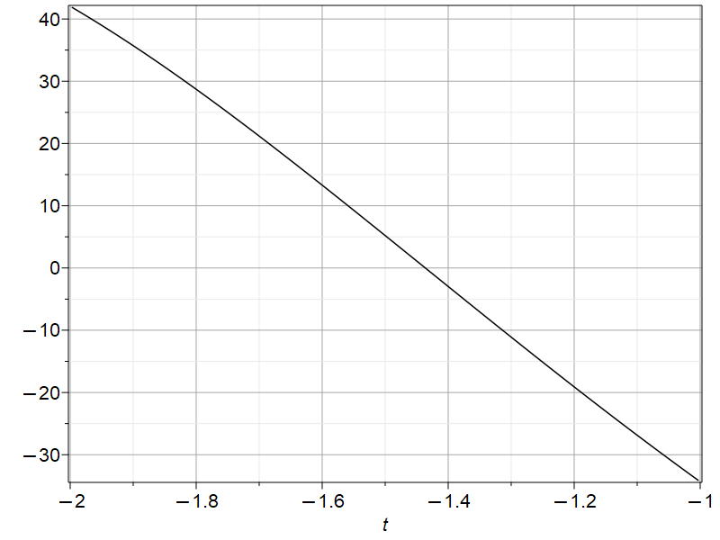

```python
plot( den, t=-2..-1, gridlines );
```

So the solution is singular for some t between about -1.5 and -1.4.

```python
fsolve(den, t=-2..-1);
```

$$- 1.436348184$$

This explains the radius of convergence of the series solution.

```python
dsolve( diff(y(x),x,x) = x*y(x), y(x) );
```

$$y \left(x \right) = c_{1} \mathit{Ai}\left(x \right)+c_{2} \mathit{Bi}\left(x \right)$$

```python
Order := 4:
expand( simplify( asympt( AiryAi(x), x ) ) ) assuming x>0;
```

$$\frac{1}{2 x^{\frac{1}{4}} \sqrt{\pi} \left({\mathrm e}^{x^{\frac{3}{2}}}\right)^{\frac{2}{3}}}-\frac{5}{96 x^{\frac{7}{4}} \sqrt{\pi} \left({\mathrm e}^{x^{\frac{3}{2}}}\right)^{\frac{2}{3}}}+\frac{385}{9216 x^{\frac{13}{4}} \sqrt{\pi} \left({\mathrm e}^{x^{\frac{3}{2}}}\right)^{\frac{2}{3}}}+O\left(\frac{1}{x^{\frac{19}{4}}}\right)$$

```python
expand( simplify( asympt( AiryBi(x), x ) ) ) assuming x>0;
```

$$\left({\mathrm e}^{x^{\frac{3}{2}}}\right)^{\frac{2}{3}} O\left(\frac{1}{x^{\frac{19}{4}}}\right)+\frac{\left({\mathrm e}^{x^{\frac{3}{2}}}\right)^{\frac{2}{3}}}{\sqrt{\pi} x^{\frac{1}{4}}}+\frac{5 \left({\mathrm e}^{x^{\frac{3}{2}}}\right)^{\frac{2}{3}}}{48 \sqrt{\pi} x^{\frac{7}{4}}}+\frac{385 \left({\mathrm e}^{x^{\frac{3}{2}}}\right)^{\frac{2}{3}}}{4608 \sqrt{\pi} x^{\frac{13}{4}}}$$

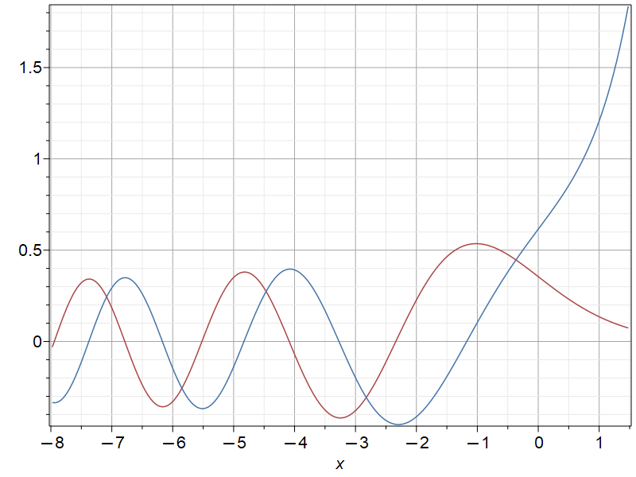

```python
plot( [AiryAi(x), AiryBi(x)], x=-8..1.5,
      color=["Executive Red", "Executive Blue"], gridlines);
```

Solving differential equations numerically is extremely important, versatile, and reliable. Maple has excellent facilities for this (comparable to Matlab's and to Python's; the features of Julia are pretty much state-of-the-art these days).

```python
wavyde := diff(y(x),x) - cos(Pi*x*y(x));
```

$$\frac{d}{d x}y \left(x \right)-\cos \left(\pi x y \left(x \right)\right)$$

```python
dsolve( wavyde, y(x) ); # No analytic solution known, no answer given
```

```
kilobytes used=108716, alloc=24074, time=10.58
```

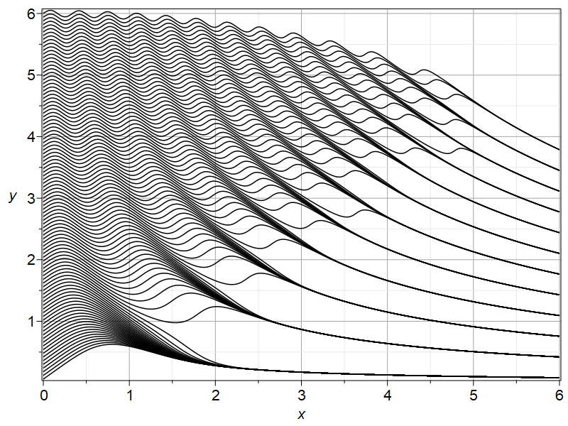

```python
N := 100: # Solve for N different initial conditions
sols := Array(1..N):
plts := Array(1..N):
for k to N do
  ic := 6.0*k/N;
  sols[k] := dsolve( {wavyde, y(0)=ic}, y(x), numeric, range=0..6,
                     abserr=1.0e-11 ); # Choose a tight tolerance
  plts[k] := plots[odeplot](sols[k], [x,y(x)] );
end do:
plots[display]( seq(plts[k],k=1..N), gridlines );
```

## A Warning. Sometimes Maple is not correct.

The following differential equation is apparently solved in Maple. But there is a hidden difficulty.

```python
nastyde := diff(y(x),x) = x^2*(x^2-y(x)^2);
```

$$\frac{d}{d x}y \left(x \right) = x^{2} \left(x^{2}-y \left(x \right)^{2}\right)$$

```python
subtlywrong := dsolve( {nastyde, y(-1)=0}, y(x) );
```

```
kilobytes used=124658, alloc=24623, time=12.55
```

$$y \left(x \right) = -\frac{x \left(I_{-\frac{5}{8}}\left(\frac{1}{4}\right) K_{\frac{5}{8}}\left(\frac{x^{4}}{4}\right)-K_{\frac{5}{8}}\left(\frac{1}{4}\right) I_{-\frac{5}{8}}\left(\frac{x^{4}}{4}\right)\right)}{K_{\frac{3}{8}}\left(\frac{x^{4}}{4}\right) I_{-\frac{5}{8}}\left(\frac{1}{4}\right)+I_{\frac{3}{8}}\left(\frac{x^{4}}{4}\right) K_{\frac{5}{8}}\left(\frac{1}{4}\right)}$$

Those "I"s and "K"s are *Bessel functions*, which are very important in a number of branches of physics and engineering.

The problem is that the differential equation has a "turning point" at $x=0$ and this breaks *algebra*. The constant of integration has to change at that point!

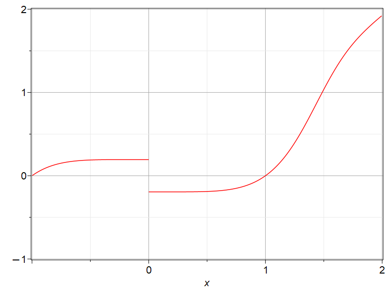

```python
testplot := plot( eval(y(x), subtlywrong), x=-1..2, discont=true,
      color=red, gridlines, view=[-1..2,-1..2]  );
```

```python
fixit := dsolve( nastyde, y(x) );
```

$$y \left(x \right) = -\frac{x c_{1} K_{\frac{11}{8}}\left(\frac{x^{4}}{4}\right)}{K_{\frac{3}{8}}\left(\frac{x^{4}}{4}\right) c_{1} +I_{\frac{3}{8}}\left(\frac{x^{4}}{4}\right)}+\frac{I_{\frac{11}{8}}\left(\frac{x^{4}}{4}\right) x^{4}+3 K_{\frac{3}{8}}\left(\frac{x^{4}}{4}\right) c_{1} +3 I_{\frac{3}{8}}\left(\frac{x^{4}}{4}\right)}{x^{3} \left(K_{\frac{3}{8}}\left(\frac{x^{4}}{4}\right) c_{1} +I_{\frac{3}{8}}\left(\frac{x^{4}}{4}\right)\right)}$$

```python
lefteq := eval( eval( y(x), fixit ), x=-1 ) = 0;
```

$$\frac{c_{1} K_{\frac{11}{8}}\left(\frac{1}{4}\right)}{K_{\frac{3}{8}}\left(\frac{1}{4}\right) c_{1} +I_{\frac{3}{8}}\left(\frac{1}{4}\right)}-\frac{I_{\frac{11}{8}}\left(\frac{1}{4}\right)+3 K_{\frac{3}{8}}\left(\frac{1}{4}\right) c_{1} +3 I_{\frac{3}{8}}\left(\frac{1}{4}\right)}{K_{\frac{3}{8}}\left(\frac{1}{4}\right) c_{1} +I_{\frac{3}{8}}\left(\frac{1}{4}\right)} = 0$$

```python
leftc1 := solve( lefteq, c__1);
```

$$\frac{3 I_{\frac{3}{8}}\left(\frac{1}{4}\right)+I_{\frac{11}{8}}\left(\frac{1}{4}\right)}{-3 K_{\frac{3}{8}}\left(\frac{1}{4}\right)+K_{\frac{11}{8}}\left(\frac{1}{4}\right)}$$

```python
leftside := eval(rhs(fixit), c__1=leftc1 );
```

$$-\frac{x \left(3 I_{\frac{3}{8}}\left(\frac{1}{4}\right)+I_{\frac{11}{8}}\left(\frac{1}{4}\right)\right) K_{\frac{11}{8}}\left(\frac{x^{4}}{4}\right)}{\left(-3 K_{\frac{3}{8}}\left(\frac{1}{4}\right)+K_{\frac{11}{8}}\left(\frac{1}{4}\right)\right) \left(\frac{K_{\frac{3}{8}}\left(\frac{x^{4}}{4}\right) \left(3 I_{\frac{3}{8}}\left(\frac{1}{4}\right)+I_{\frac{11}{8}}\left(\frac{1}{4}\right)\right)}{-3 K_{\frac{3}{8}}\left(\frac{1}{4}\right)+K_{\frac{11}{8}}\left(\frac{1}{4}\right)}+I_{\frac{3}{8}}\left(\frac{x^{4}}{4}\right)\right)}+\frac{I_{\frac{11}{8}}\left(\frac{x^{4}}{4}\right) x^{4}+\frac{3 K_{\frac{3}{8}}\left(\frac{x^{4}}{4}\right) \left(3 I_{\frac{3}{8}}\left(\frac{1}{4}\right)+I_{\frac{11}{8}}\left(\frac{1}{4}\right)\right)}{-3 K_{\frac{3}{8}}\left(\frac{1}{4}\right)+K_{\frac{11}{8}}\left(\frac{1}{4}\right)}+3 I_{\frac{3}{8}}\left(\frac{x^{4}}{4}\right)}{x^{3} \left(\frac{K_{\frac{3}{8}}\left(\frac{x^{4}}{4}\right) \left(3 I_{\frac{3}{8}}\left(\frac{1}{4}\right)+I_{\frac{11}{8}}\left(\frac{1}{4}\right)\right)}{-3 K_{\frac{3}{8}}\left(\frac{1}{4}\right)+K_{\frac{11}{8}}\left(\frac{1}{4}\right)}+I_{\frac{3}{8}}\left(\frac{x^{4}}{4}\right)\right)}$$

```python
tomatch := limit( leftside, x=0, left );
```

$$\frac{-2 \,2^{\frac{3}{4}} \Gamma \left(\frac{5}{8}\right)^{2} K_{\frac{11}{8}}\left(\frac{1}{4}\right) \sin \left(\frac{3 \pi}{8}\right)+6 \,2^{\frac{3}{4}} \Gamma \left(\frac{5}{8}\right)^{2} K_{\frac{3}{8}}\left(\frac{1}{4}\right) \sin \left(\frac{3 \pi}{8}\right)+3 \,2^{\frac{3}{4}} \Gamma \left(\frac{5}{8}\right)^{2} \pi I_{\frac{3}{8}}\left(\frac{1}{4}\right)+2^{\frac{3}{4}} \Gamma \left(\frac{5}{8}\right)^{2} \pi I_{\frac{11}{8}}\left(\frac{1}{4}\right)}{3 \csc \left(\frac{3 \pi}{8}\right) \pi^{2} I_{\frac{3}{8}}\left(\frac{1}{4}\right)+\csc \left(\frac{3 \pi}{8}\right) \pi^{2} I_{\frac{11}{8}}\left(\frac{1}{4}\right)}$$

```python
rightc1eq := limit( rhs(fixit), x=0, right );
```

$$\frac{-2^{\frac{3}{4}} \Gamma \left(\frac{5}{8}\right)^{2} c_{1} \pi +2 \,2^{\frac{3}{4}} \Gamma \left(\frac{5}{8}\right)^{2} \sin \left(\frac{3 \pi}{8}\right)}{\pi^{2} \csc \left(\frac{3 \pi}{8}\right) c_{1}}$$

```python
rightc1 := solve( rightc1eq=tomatch, c__1);
```

$$-\frac{\sin \left(\frac{3 \pi}{8}\right) \left(3 I_{\frac{3}{8}}\left(\frac{1}{4}\right)+I_{\frac{11}{8}}\left(\frac{1}{4}\right)\right)}{K_{\frac{11}{8}}\left(\frac{1}{4}\right) \sin \left(\frac{3 \pi}{8}\right)-3 K_{\frac{3}{8}}\left(\frac{1}{4}\right) \sin \left(\frac{3 \pi}{8}\right)-3 \pi I_{\frac{3}{8}}\left(\frac{1}{4}\right)-\pi I_{\frac{11}{8}}\left(\frac{1}{4}\right)}$$

```python
rightside := eval(fixit, c__1=rightc1 );
```

$$y \left(x \right) = \frac{x \sin \left(\frac{3 \pi}{8}\right) \left(3 I_{\frac{3}{8}}\left(\frac{1}{4}\right)+I_{\frac{11}{8}}\left(\frac{1}{4}\right)\right) K_{\frac{11}{8}}\left(\frac{x^{4}}{4}\right)}{\left(K_{\frac{11}{8}}\left(\frac{1}{4}\right) \sin \left(\frac{3 \pi}{8}\right)-3 K_{\frac{3}{8}}\left(\frac{1}{4}\right) \sin \left(\frac{3 \pi}{8}\right)-3 \pi I_{\frac{3}{8}}\left(\frac{1}{4}\right)-\pi I_{\frac{11}{8}}\left(\frac{1}{4}\right)\right) \left(-\frac{K_{\frac{3}{8}}\left(\frac{x^{4}}{4}\right) \sin \left(\frac{3 \pi}{8}\right) \left(3 I_{\frac{3}{8}}\left(\frac{1}{4}\right)+I_{\frac{11}{8}}\left(\frac{1}{4}\right)\right)}{K_{\frac{11}{8}}\left(\frac{1}{4}\right) \sin \left(\frac{3 \pi}{8}\right)-3 K_{\frac{3}{8}}\left(\frac{1}{4}\right) \sin \left(\frac{3 \pi}{8}\right)-3 \pi I_{\frac{3}{8}}\left(\frac{1}{4}\right)-\pi I_{\frac{11}{8}}\left(\frac{1}{4}\right)}+I_{\frac{3}{8}}\left(\frac{x^{4}}{4}\right)\right)}+\frac{I_{\frac{11}{8}}\left(\frac{x^{4}}{4}\right) x^{4}-\frac{3 K_{\frac{3}{8}}\left(\frac{x^{4}}{4}\right) \sin \left(\frac{3 \pi}{8}\right) \left(3 I_{\frac{3}{8}}\left(\frac{1}{4}\right)+I_{\frac{11}{8}}\left(\frac{1}{4}\right)\right)}{K_{\frac{11}{8}}\left(\frac{1}{4}\right) \sin \left(\frac{3 \pi}{8}\right)-3 K_{\frac{3}{8}}\left(\frac{1}{4}\right) \sin \left(\frac{3 \pi}{8}\right)-3 \pi I_{\frac{3}{8}}\left(\frac{1}{4}\right)-\pi I_{\frac{11}{8}}\left(\frac{1}{4}\right)}+3 I_{\frac{3}{8}}\left(\frac{x^{4}}{4}\right)}{x^{3} \left(-\frac{K_{\frac{3}{8}}\left(\frac{x^{4}}{4}\right) \sin \left(\frac{3 \pi}{8}\right) \left(3 I_{\frac{3}{8}}\left(\frac{1}{4}\right)+I_{\frac{11}{8}}\left(\frac{1}{4}\right)\right)}{K_{\frac{11}{8}}\left(\frac{1}{4}\right) \sin \left(\frac{3 \pi}{8}\right)-3 K_{\frac{3}{8}}\left(\frac{1}{4}\right) \sin \left(\frac{3 \pi}{8}\right)-3 \pi I_{\frac{3}{8}}\left(\frac{1}{4}\right)-\pi I_{\frac{11}{8}}\left(\frac{1}{4}\right)}+I_{\frac{3}{8}}\left(\frac{x^{4}}{4}\right)\right)}$$

```python
leftside := simplify(leftside) assuming x<0;
```

$$-\frac{x \left(I_{-\frac{5}{8}}\left(\frac{1}{4}\right) K_{\frac{5}{8}}\left(\frac{x^{4}}{4}\right)-K_{\frac{5}{8}}\left(\frac{1}{4}\right) I_{-\frac{5}{8}}\left(\frac{x^{4}}{4}\right)\right)}{K_{\frac{3}{8}}\left(\frac{x^{4}}{4}\right) I_{-\frac{5}{8}}\left(\frac{1}{4}\right)+I_{\frac{3}{8}}\left(\frac{x^{4}}{4}\right) K_{\frac{5}{8}}\left(\frac{1}{4}\right)}$$

```python
rightside := simplify(rhs(rightside)) assuming x>0;
```

$$\frac{\left(\left(\pi I_{-\frac{5}{8}}\left(\frac{1}{4}\right)-K_{\frac{5}{8}}\left(\frac{1}{4}\right) \cos \left(\frac{\pi}{8}\right)\right) I_{-\frac{5}{8}}\left(\frac{x^{4}}{4}\right)-I_{-\frac{5}{8}}\left(\frac{1}{4}\right) \cos \left(\frac{\pi}{8}\right) K_{\frac{5}{8}}\left(\frac{x^{4}}{4}\right)\right) x}{\left(\pi I_{-\frac{5}{8}}\left(\frac{1}{4}\right)-K_{\frac{5}{8}}\left(\frac{1}{4}\right) \cos \left(\frac{\pi}{8}\right)\right) I_{\frac{3}{8}}\left(\frac{x^{4}}{4}\right)+I_{-\frac{5}{8}}\left(\frac{1}{4}\right) \cos \left(\frac{\pi}{8}\right) K_{\frac{3}{8}}\left(\frac{x^{4}}{4}\right)}$$

```python
goodsolution := piecewise(x<0,leftside,rightside):
```

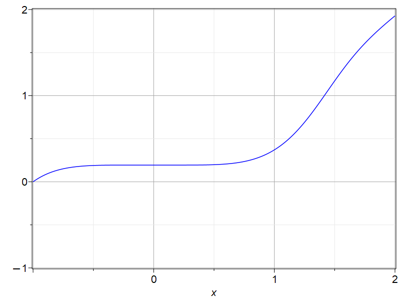

```python
fixedplot := plot( goodsolution, x=-1..2, view=[-1..2,-1..2], gridlines, colour=blue);
```

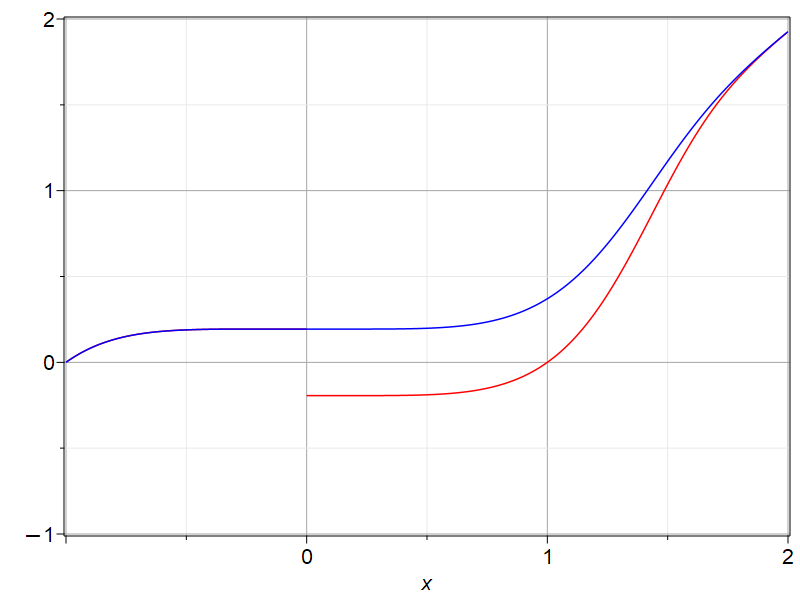

```python
plots[display]( testplot, fixedplot );
```

There's a lot more to be said about differential equations in Maple. One can use Maple to vary parameters and see what happens. One can build applets with sliders to do so. One can examine differential equations that do not satisfy Lipschitz conditions and have more than one solution. One can solve problems with "moveable poles." One can solve problems *approximately* using perturbation methods (I am currently writing a book with Nic Fillion on just that, and wow do I ever want to tell you more about that, but your professor says that should wait till "next year" :).

## Remember: always plot your solutions.

When you use Maple, or any computer algebra system, be careful, and don't expect too much. But a lot of work by a lot of people has gone into the systems over the years (decades!) and they can be very useful indeed.